# Human Activity Recognition

## identifying Correlated Predictors

(from http://topepo.github.io/caret/preprocess.html)

```r
training_col_removed_wo <- training_col_removed[ , -ncol(training_col_removed)]

descrCor <-  cor(data.matrix(training_col_removed_wo)) # numeric values in a matrix are mandatory ; therefore I remove the "classe" and make a matrix
highCorr <- sum(abs(descrCor[upper.tri(descrCor)]) > .98) # threshold set at 98% correlation
highCorr
```

```
## [1] 2
```

this value shows the number of correlated variables with a value above 98% (look at min and max (careful with abs below)).

```r
summary(descrCor[upper.tri(descrCor)])
```

```
##      Min.   1st Qu.    Median      Mean   3rd Qu.      Max.
## -0.992000 -0.110100  0.002092  0.001790  0.092550  0.980900
```

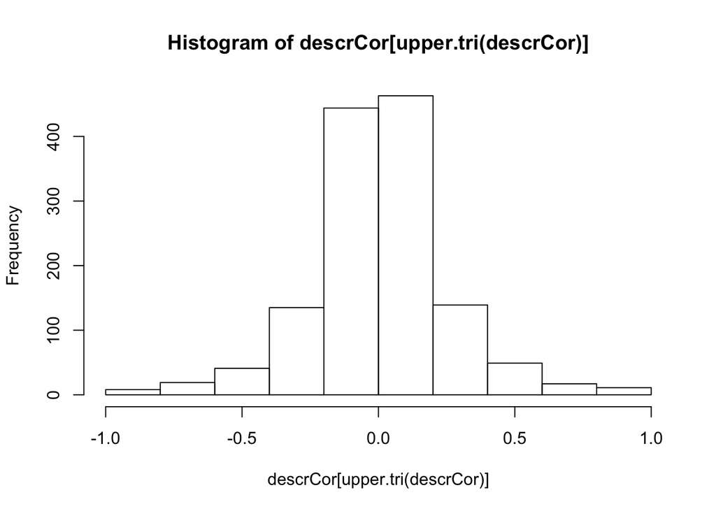

```r
hist(descrCor[upper.tri(descrCor)])
```

I choose to remove the predictors showing a correlation above 80%.

```r
highlyCorDescr <- findCorrelation(descrCor, cutoff = .8)
filteredDescr <- training_col_removed_wo[,-highlyCorDescr] # this is my training dataset w/o correlated predictors
descrCor2 <- cor(filteredDescr)
summary(descrCor2[upper.tri(descrCor2)])
```

```
##      Min.   1st Qu.    Median      Mean   3rd Qu.      Max.
## -0.768700 -0.093330  0.007589  0.013910  0.099910  0.780600
```

I am left with

```r
dim(filteredDescr)[2]
```

```
## [1] 40
```

predictors.

The same predictors must be removed in the testing due to correlation in the training dataset.

```r
filtered_testing <- testing_col_removed[,-highlyCorDescr]
```

I check if all of the column names are identical :

```r
table(names(filtered_testing) == names(filteredDescr))
```

```
##
## TRUE
##   40
```

Because there are only TRUE, that means I have got a cleaned training and testing dataset that contain no correlated predictors.

## Linear depencies

(from http://topepo.github.io/caret/preprocess.html) For the sake of completeness, I check if there are linear dependencies between predictors that would be detected by another caret package function

```r
findLinearCombos(filteredDescr)
```

```
## $linearCombos
## list()
##
## $remove
## NULL
```

The list is empty, there is no linear dependencies. I just rebuild my training dataset with the “classe”.

```r
training_ready <- cbind(training$classe, filteredDescr)
colnames(training_ready)[1] <- "classe"
```

There is no classe column in the testing dataset, because it is what I am supposed to predict !

# CV - data splitting

A part of the training dataset will be used as a CV dataset, for assessing the test error. A 30% part is or CV.

```r
inTrain <- createDataPartition(y = training_ready$classe, p = 0.7, list = FALSE)
training_ds <- training_ready[inTrain, ]
valid_ds <- training_ready[-inTrain, ]
```

# Random Forest

The Random Forest technique is often the most powerful of all. Therefore I go directly with this technique.

```r
rf_model <- randomForest(classe ~ ., data = training_ds )
rf_model
```

```
##
## Call:
##  randomForest(formula = classe ~ ., data = training_ds)
##                Type of random forest: classification
##                      Number of trees: 500
## No. of variables tried at each split: 6
##
##         OOB estimate of  error rate: 0.68%
## Confusion matrix:
##      A    B    C    D    E  class.error
## A 3904    1    0    0    1 0.0005120328
## B   17 2635    6    0    0 0.0086531226
## C    0   23 2367    6    0 0.0121035058
## D    0    0   30 2219    3 0.0146536412
## E    0    0    1    6 2518 0.0027722772
```

The error rate, as well as the accuracy, is written in the output of the model.

# CV

```r
valid_predict <- predict(rf_model, valid_ds)
confusionMatrix(valid_predict, valid_ds$classe)
```

```
## Confusion Matrix and Statistics
##
##           Reference
## Prediction    A    B    C    D    E
##          A 1672   11    0    0    0
##          B    2 1124   20    0    0
##          C    0    4 1006   13    0
##          D    0    0    0  951    4
##          E    0    0    0    0 1078
##
## Overall Statistics
##
##                Accuracy : 0.9908
##                  95% CI : (0.988, 0.9931)
##     No Information Rate : 0.2845
##     P-Value [Acc > NIR] : < 2.2e-16
##
##                   Kappa : 0.9884
##  Mcnemar's Test P-Value : NA
##
## Statistics by Class:
##
##                      Class: A Class: B Class: C Class: D Class: E
## Sensitivity            0.9988   0.9868   0.9805   0.9865   0.9963
## Specificity            0.9974   0.9954   0.9965   0.9992   1.0000
## Pos Pred Value         0.9935   0.9808   0.9834   0.9958   1.0000
## Neg Pred Value         0.9995   0.9968   0.9959   0.9974   0.9992
## Prevalence             0.2845   0.1935   0.1743   0.1638   0.1839
## Detection Rate         0.2841   0.1910   0.1709   0.1616   0.1832
## Detection Prevalence   0.2860   0.1947   0.1738   0.1623   0.1832
## Balanced Accuracy      0.9981   0.9911   0.9885   0.9929   0.9982
```

The accuracy is (in %)

```r
unname(100*(confusionMatrix(valid_predict, valid_ds$classe)$overall[1]))
```

```
## [1] 99.08241
```

and the estimtated error rate is (in %) about

```r
unname(100*(1-confusionMatrix(valid_predict, valid_ds$classe)$overall[1]))
```

```
## [1] 0.9175871
```

# Prediction

On the testing dataset, the 20 predicted classes are :

```r
predict(rf_model, testing_col_removed)
```

```
##  1  2  3  4  5  6  7  8  9 10 11 12 13 14 15 16 17 18 19 20
##  B  A  B  A  A  E  D  B  A  A  B  C  B  A  E  E  A  B  B  B
## Levels: A B C D E
```

This renders 100% correct answers when submitted in the course website.

# Discussion

## Integrated CV

```r
rf_model_cv <- randomForest(classe ~ ., data = training_ds , ytest = valid_ds$classe , xtest =valid_ds[, -1] )
rf_model_cv
```

```
##
## Call:
##  randomForest(formula = classe ~ ., data = training_ds, ytest = valid_ds$classe,      xtest = valid_ds[, -1])
##                Type of random forest: classification
##                      Number of trees: 500
## No. of variables tried at each split: 6
##
##         OOB estimate of  error rate: 0.69%
## Confusion matrix:
##      A    B    C    D    E  class.error
## A 3903    2    0    0    1 0.0007680492
## B   17 2633    7    0    1 0.0094055681
## C    0   29 2363    4    0 0.0137729549
## D    0    0   27 2223    2 0.0128774423
## E    0    0    1    4 2520 0.0019801980
##                 Test set error rate: 0.92%
## Confusion matrix:
##      A    B    C   D    E class.error
## A 1672    2    0   0    0 0.001194743
## B   10 1126    3   0    0 0.011413521
## C    0   18 1008   0    0 0.017543860
## D    0    0   17 947    0 0.017634855
## E    0    0    0   4 1078 0.003696858
```

## Predictors

It was a deliberate choice not to remove other predictors (except the one higher based on correlation).

I am left with

```r
dim(filteredDescr)[2]
```

```
## [1] 40
```

predictors. All of them are used in the prediction model.

The importance of predictors on the prediction is shown in the graph below :

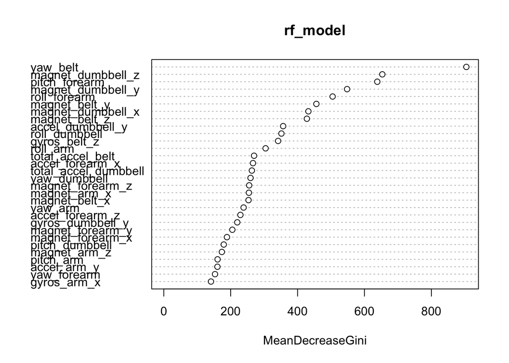

```r
varImpPlot(rf_model,)
```

## Other prediction model

Another model is tested and its accuracy compared to the one from Random Forest.

```r
rpart_model <- train(classe ~ ., method = "rpart", data = training_ds)
rpart_model
```

```
## CART
##
## 13737 samples
##    40 predictor
##     5 classes: 'A', 'B', 'C', 'D', 'E'
##
## No pre-processing
## Resampling: Bootstrapped (25 reps)
##
## Summary of sample sizes: 13737, 13737, 13737, 13737, 13737, 13737, ...
##
## Resampling results across tuning parameters:
##
##   cp         Accuracy   Kappa      Accuracy SD  Kappa SD
##   0.0197335  0.5738084  0.4601615  0.02970345   0.04079123
##   0.0277693  0.5292542  0.3983879  0.02331748   0.03745104
##   0.0429763  0.4400057  0.2604696  0.09217450   0.15312914
##
## Accuracy was used to select the optimal model using  the largest value.
## The final value used for the model was cp = 0.0197335.
```

```r
valid_predict_rpart <- predict(rpart_model, valid_ds)
confusionMatrix(valid_predict_rpart, valid_ds$classe)
```

```
## Confusion Matrix and Statistics
##
##           Reference
## Prediction    A    B    C    D    E
##          A 1162  239   37   53   22
##          B   23  505   31   61  243
##          C  306  235  806  203  266
##          D  183  157  152  562  209
##          E    0    3    0   85  342
##
## Overall Statistics
##
##                Accuracy : 0.5738
##                  95% CI : (0.5611, 0.5865)
##     No Information Rate : 0.2845
##     P-Value [Acc > NIR] : < 2.2e-16
##
##                   Kappa : 0.4647
##  Mcnemar's Test P-Value : < 2.2e-16
##
## Statistics by Class:
##
##                      Class: A Class: B Class: C Class: D Class: E
## Sensitivity            0.6941  0.44337   0.7856   0.5830  0.31608
## Specificity            0.9166  0.92457   0.7921   0.8575  0.98168
## Pos Pred Value         0.7680  0.58517   0.4438   0.4450  0.79535
## Neg Pred Value         0.8829  0.87376   0.9459   0.9130  0.86434
## Prevalence             0.2845  0.19354   0.1743   0.1638  0.18386
## Detection Rate         0.1975  0.08581   0.1370   0.0955  0.05811
## Detection Prevalence   0.2571  0.14664   0.3086   0.2146  0.07307
## Balanced Accuracy      0.8054  0.68397   0.7889   0.7203  0.64888
```

The accuracy is (in %)

```r
unname(100*(confusionMatrix(valid_predict_rpart, valid_ds$classe)$overall[1]))
```

```
## [1] 57.38318
```

and the estimtated error rate is (in %) about

```r
unname(100*(1-confusionMatrix(valid_predict_rpart, valid_ds$classe)$overall[1]))
```

```
## [1] 42.61682
```

Based on these indicators, one can conclude that this model is much less accurate that the model based on Random Forest.

# Conclusion

The accuracy of the model is excellent, one can even think of overfitting, although the test error seems low when using a validation set.

The accuracy is (in %)

```r
unname(100*(confusionMatrix(valid_predict, valid_ds$classe)$overall[1]))
```

```
## [1] 99.08241
```

and the estimtated error rate is (in %) about

```r
unname(100*(1-confusionMatrix(valid_predict, valid_ds$classe)$overall[1]))
```

```
## [1] 0.9175871
```

Removing some predictors does not seem to lower the prediction performance of the model, as the prediction basd on the testing set was 100% right. To recall, the original training dataset contains about 150 predictors and the model is based upon 40 predictors.

Preprocessing function was not used but removing the predictors based on near zero variance, as I did, is similar to a PCA processing for instance, as PCA is based upon maximal variance among the predictors.

Based on the prediction result, I can conclude that my way of doing this small prediction project was correct, even though there are many other ways !

# Reference

Ugulino, W.; Cardador, D.; Vega, K.; Velloso, E.; Milidiu, R.; Fuks, H. Wearable Computing: Accelerometers Data Classification of Body Postures and Movements. Proceedings of 21st Brazilian Symposium on Artificial Intelligence. Advances in Artificial Intelligence - SBIA 2012. In: Lecture Notes in Computer Science. , pp. 52-61. Curitiba, PR: Springer Berlin / Heidelberg, 2012. ISBN 978-3-642-34458-9. DOI: 10.1007/978-3-642-34459-6_6.

Read more: http://groupware.les.inf.puc-rio.br/har#ixzz3XAuCoJYn